# Question 1: with t-1 variable

Mary Fisher

February 28; Updated March 13

#### Research Question: Which oceanographic and herbivory conditions are important for predicting giant kelp size and abundance?

**Response variables:** Giant kelp total biomass

**Predictor variables:**

1. Urchin abundance: Sea urchins are herbivores, and in large numbers (also called “herds”) can decimate kelp forests. We have three measures of urchin abundance - red urchin abundance, purple urchin abundance, and urchin abundance across all species.
2. Water chemistry: Like any algae / plant, kelp requires nutrients to grow. We have measurements for the following nutrients: nitrogen, ammonia, urea, and phosphorus. We also have chlorophyl concentrations, which is a general index of primary productivity.
3. Water temperature: All species have a thermal range, or a range of temperatures, at which they grow best; the degree of variability in temperature can also have an impact on growth. With kelp forest loss from recent marine heatwaves and long-term warming, there has been much interest in whether kelp are impacted by an absolute temperature threshold, or by the degree of variability in temperature. We have mean summer and mean winter temperatures, and variation in summer and mean winter temperatures.
4. Giant kelp mean / max abundance, mean / max size at t-1: This data set is a time series, so the giant kelp response variable at a given site for year `t` should be dependent on giant kelp condition in year `t-1`.

**Modeling approach:** OLS incorporating previous size / abundance.

# Prepare Data

Read in data

```r
mydat <- read.csv(here::here("data","kelp_prediction_data_complete.csv")) %>%
  clean_names()
mydat <- mydat[,-c(2,4:9)]
head(mydat)
```

```
##   year site franciscanus_abundance purpuratus_abundance urchin_abundance
## 1 2002 CARP              6.7500000          264.8750000       271.625000
## 2 2002 NAPL             15.8750000           85.1250000       101.000000
## 3 2003 AQUE              0.8333333            0.6666667         1.500000
## 4 2003 CARP              6.7500000          174.0000000       180.750000
## 5 2003 NAPL              7.7500000           25.0000000        32.750000
## 6 2004 AQUE              0.1666667            1.0000000         1.166667
##   max_ammonia max_no2_no3 max_po4  max_poc max_pon max_tchl mean_ammonia
## 1        1397        1008    1495 102.0781 11.4341  10.2905    1397.0000
## 2         454        1295    1374  54.1086  7.4780   4.6217     247.0000
## 3        1607        1709    1997 351.5885 45.1321  68.6997     622.2222
## 4        1668        1716    1851 927.0821 85.0700 114.6230    1024.4444
## 5        1150        1525    1368 131.4253 15.1567  18.2213     486.4286
## 6        1596        1567    1749  66.7771 10.4241   9.5370    1180.8889
##   mean_no2_no3  mean_po4  mean_poc  mean_pon mean_tchl summer_mean_temp
## 1     780.0000  970.7143  37.21842  5.287922  3.112844         15.08927
## 2     560.5000  827.5000  31.76975  4.859070  2.754970         14.80463
## 3     769.4286  977.1111  68.07417  9.547727 10.742045         15.14012
## 4     581.5714 1157.1429 144.00902 15.385956 17.143778         15.95633
## 5     469.0000  505.6250  51.91268  6.819100  6.041510         15.85466
## 6     741.4286  840.0000  36.20107  5.695850  3.836111         16.21198
##   summer_var_temp winter_mean_temp winter_var_temp
## 1       0.9788605         15.41466       0.5318180
## 2       0.8942802         15.23370       0.4793251
## 3       2.1303877         12.90533       4.3133960
## 4       2.5297596         14.36140       2.3755785
## 5       2.2429375         13.89622       3.2840020
## 6       3.7084984         14.36841       3.0687381
```

Read in kelp total biomass

```
##  [1] "year"                   "site"                   "franciscanus_abundance"
##  [4] "purpuratus_abundance"   "urchin_abundance"       "max_ammonia"
##  [7] "max_no2_no3"            "max_po4"                "max_poc"
## [10] "max_pon"                "max_tchl"               "mean_ammonia"
## [13] "mean_no2_no3"           "mean_po4"               "mean_poc"
## [16] "mean_pon"               "mean_tchl"              "summer_mean_temp"
## [19] "summer_var_temp"        "winter_mean_temp"       "winter_var_temp"
## [22] "kelp_total_biomass"
```

Add in the giant kelp response variables for `t-1`.

```
##
## There are 0 missing measurements for the previous year's kelp abundance.
```

```
##  [1] "year"                   "site"                   "franciscanus_abundance"
##  [4] "purpuratus_abundance"   "urchin_abundance"       "max_ammonia"
##  [7] "max_no2_no3"            "max_po4"                "max_poc"
## [10] "max_pon"                "max_tchl"               "mean_ammonia"
## [13] "mean_no2_no3"           "mean_po4"               "mean_poc"
## [16] "mean_pon"               "mean_tchl"              "summer_mean_temp"
## [19] "summer_var_temp"        "winter_mean_temp"       "winter_var_temp"
## [22] "kelp_total_biomass"     "prev_total_biomass"
```

## Predictor Variables

### Herbivory

We have three variables that quantify urchin abundance - we’ll just work with total abundance (`urchin_abundance`).

This variable is zero-inflated, a common problem with ecological count data. So I’m going to split it into two predictor variables - a categorical presence / absence variable, and then an abundance variable.

First, get rid of the species-specific counts

```r
lmdat <- dplyr::select(mydat, -purpuratus_abundance,-franciscanus_abundance)
```

Then grab the total abundance data and split it into the two new variables. Does the square root transformation of the urchin abundance variable look normal?

```r
lmdat <- lmdat %>%
  mutate(urchin_presence = ifelse(urchin_abundance > 0, 1, 0),
         urchin_abundance = ifelse(urchin_abundance==0,0,sqrt(urchin_abundance)))
```

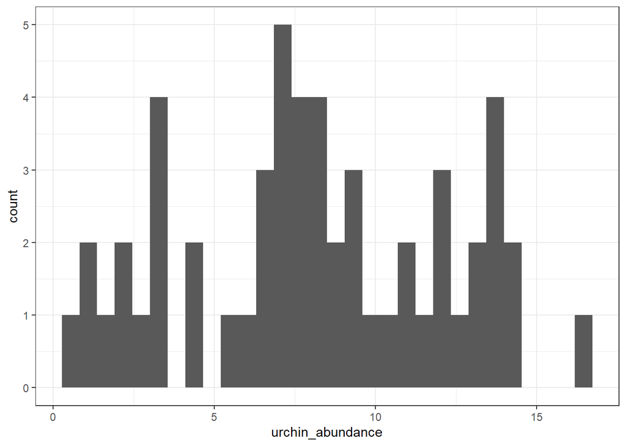

```
##
##  Shapiro-Wilk normality test
##
## data:  lmdat$urchin_abundance
## W = 0.92827, p-value = 0.0008325
```

### Water Chemistry

The maximum values of water chemistry estimates were very difficult to force into a normal distribution. So I’m only going to work with the mean values.

```r
lmdat <- lmdat %>%
  dplyr::select(-max_ammonia,-max_no2_no3,-max_po4,-max_poc,-max_pon,-max_tchl)
colnames(lmdat)
```

```
##  [1] "year"               "site"               "urchin_abundance"
##  [4] "mean_ammonia"       "mean_no2_no3"       "mean_po4"
##  [7] "mean_poc"           "mean_pon"           "mean_tchl"
## [10] "summer_mean_temp"   "summer_var_temp"    "winter_mean_temp"
## [13] "winter_var_temp"    "kelp_total_biomass" "prev_total_biomass"
## [16] "urchin_presence"
```

### Multicolinearity

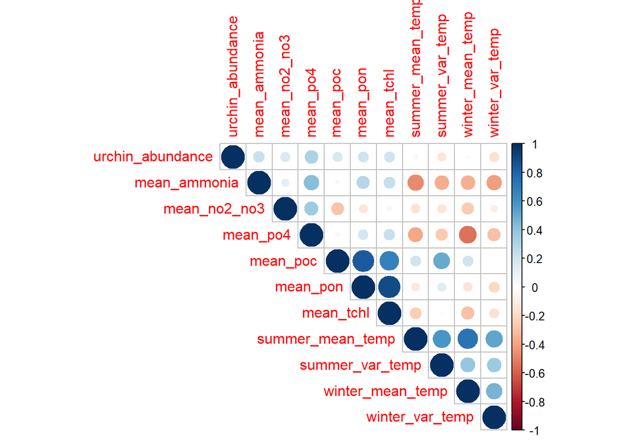

Summer and winter temperatures are correlated; since kelp is a cold-water species, we’ll stick with summer temperature only. I’ll rely on variable selection to remove either mean or variance in temperature, which are also correlated with each other.

```r
lmdat <- lmdat %>%
  dplyr::select(-winter_mean_temp,-winter_var_temp)
```

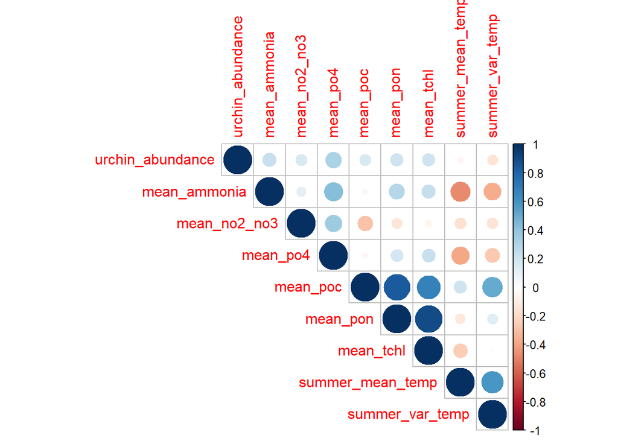

Particulate organic carbon (`poc`) is highly correlated with particulate organic nitrogen and mean total chlorophyll. I’ll remove particulate organic carbon.

```r
lmdat <- lmdat %>%
  dplyr::select(-mean_poc)
```

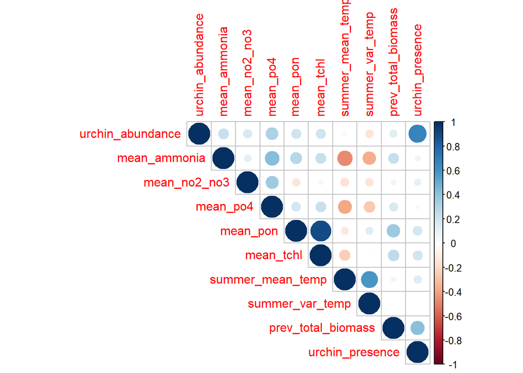

I think that for the remaining correlations, I’ll see what happens in stepwise model selection. These are the final variables:

```
##  [1] "year"               "site"               "urchin_abundance"
##  [4] "mean_ammonia"       "mean_no2_no3"       "mean_po4"
##  [7] "mean_pon"           "mean_tchl"          "summer_mean_temp"
## [10] "summer_var_temp"    "kelp_total_biomass" "prev_total_biomass"
## [13] "urchin_presence"
```

### Transform variables

According to the script [04_explore_predictors](https://github.com/mfisher5/504_BiodivSB/tree/master/scripts), many of the predictor variables are not normally distributed.

```r
lmdat.t <- lmdat %>%
  mutate(summer_var_temp = log(summer_var_temp),
         mean_pon= log(mean_pon),
         mean_tchl= log(mean_tchl))
```

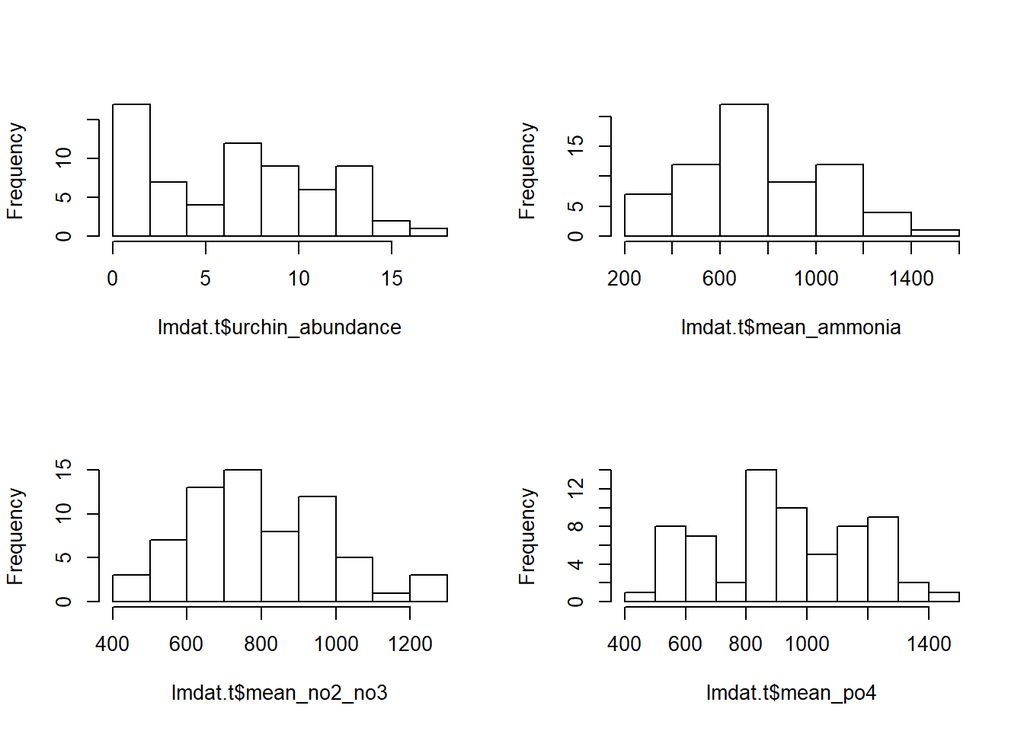

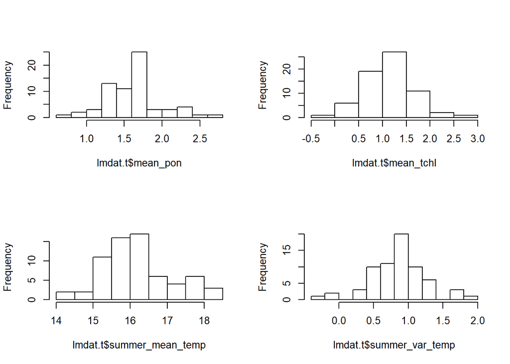

## Response Variables

Kelp total biomass needs to be raised to the (1/3)

```r
lmdat.t <- lmdat.t %>%
  mutate(prev_total_biomass=(prev_total_biomass)^(1/3))
```

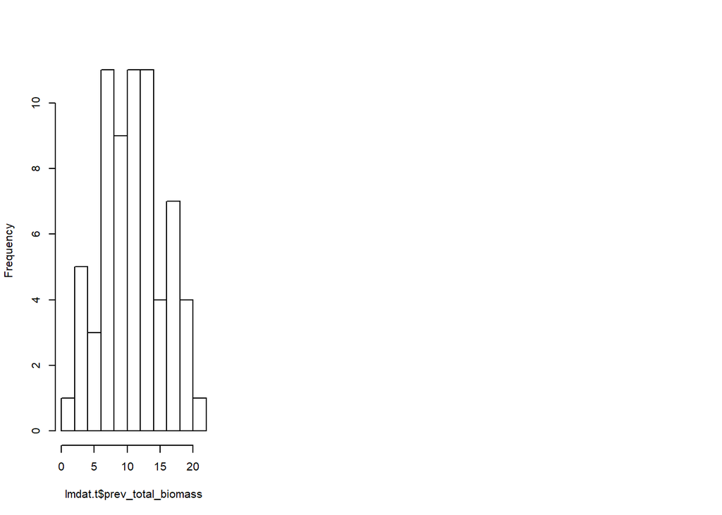

So now I have the following variables:

```
##  [1] "year"               "site"               "urchin_abundance"
##  [4] "mean_ammonia"       "mean_no2_no3"       "mean_po4"
##  [7] "mean_pon"           "mean_tchl"          "summer_mean_temp"
## [10] "summer_var_temp"    "kelp_total_biomass" "prev_total_biomass"
## [13] "urchin_presence"
```

# Model Selection (OLS)

*Response:* (`kelp_total_biomass`) ^ (1/3)

Interactions: site by previous total biomass

#### Backward model selection

```
## Start:  AIC=184.8
## (kelp_total_biomass)^(1/3) ~ site + urchin_presence + urchin_abundance +
##     prev_total_biomass + site:prev_total_biomass + mean_ammonia +
##     mean_no2_no3 + mean_po4 + mean_tchl + mean_pon + summer_mean_temp +
##     summer_var_temp
##
##
## Step:  AIC=184.8
## (kelp_total_biomass)^(1/3) ~ site + urchin_abundance + prev_total_biomass +
##     mean_ammonia + mean_no2_no3 + mean_po4 + mean_tchl + mean_pon +
##     summer_mean_temp + summer_var_temp + site:prev_total_biomass
##
##                           Df Sum of Sq    RSS    AIC
## - site:prev_total_biomass  4    13.430 354.90 170.56
## - mean_no2_no3             1     0.056 341.52 180.60
## - mean_pon                 1     0.182 341.65 180.63
## - mean_po4                 1     1.962 343.43 180.98
## - summer_var_temp          1     5.183 346.65 181.60
## - mean_tchl                1     6.909 348.37 181.94
## - summer_mean_temp         1     7.853 349.32 182.12
## <none>                                 341.47 184.80
## - mean_ammonia             1    30.896 372.36 186.40
## - urchin_abundance         1   151.017 492.48 205.13
##
## Step:  AIC=170.56
## (kelp_total_biomass)^(1/3) ~ site + urchin_abundance + prev_total_biomass +
##     mean_ammonia + mean_no2_no3 + mean_po4 + mean_tchl + mean_pon +
##     summer_mean_temp + summer_var_temp
##
##                      Df Sum of Sq    RSS    AIC
## - mean_pon            1     0.024 354.92 166.36
## - mean_no2_no3        1     0.746 355.64 166.50
## - summer_mean_temp    1     4.860 359.76 167.27
## - mean_tchl           1     5.444 360.34 167.38
## - summer_var_temp     1     6.298 361.19 167.54
## - mean_po4            1     9.064 363.96 168.05
## - prev_total_biomass  1    14.550 369.45 169.05
## <none>                            354.90 170.56
## - mean_ammonia        1    31.077 385.97 171.98
## - site                4   212.305 567.20 185.16
```

[output cut: 69 more lines]

```
## - mean_ammonia        1     29.89 407.09 154.53
## - summer_var_temp     1     35.79 412.99 155.49
## - site                4    347.85 725.05 180.59
## - urchin_abundance    1    250.56 627.76 183.55
##
## Step:  AIC=152.04
## (kelp_total_biomass)^(1/3) ~ site + urchin_abundance + mean_ammonia +
##     summer_var_temp
##
##                    Df Sum of Sq     RSS    AIC
## <none>                           392.24 152.04
## - summer_var_temp   1     46.38  438.63 155.32
## - mean_ammonia      1     51.20  443.44 156.05
## - urchin_abundance  1    364.90  757.14 191.90
## - site              4    803.09 1195.33 209.88
```

#### Forward Model Selection

```
## Start:  AIC=202.53
## (kelp_total_biomass)^(1/3) ~ 1
##
##                      Df Sum of Sq     RSS    AIC
## + prev_total_biomass  1    549.57  743.47 169.65
## + urchin_presence     1    438.02  855.02 179.02
## + site                4    490.62  802.43 187.38
## + mean_pon            1    132.88 1160.17 199.47
## + summer_mean_temp    1     95.56 1197.49 201.59
## + mean_tchl           1     90.45 1202.60 201.88
## <none>                            1293.05 202.53
## + summer_var_temp     1     40.50 1252.55 204.60
## + mean_po4            1     30.43 1262.62 205.14
## + mean_ammonia        1     16.63 1276.42 205.87
## + urchin_abundance    1     15.64 1277.40 205.92
## + mean_no2_no3        1      0.91 1292.13 206.69
##
## Step:  AIC=169.65
## (kelp_total_biomass)^(1/3) ~ prev_total_biomass
##
##                    Df Sum of Sq    RSS    AIC
## + urchin_presence   1    79.104 664.37 166.32
## + mean_po4          1    78.836 664.64 166.35
## <none>                          743.47 169.65
## + summer_mean_temp  1    44.071 699.40 169.76
## + summer_var_temp   1    17.927 725.55 172.22
## + mean_pon          1    13.681 729.79 172.62
## + mean_tchl         1     6.976 736.50 173.23
## + urchin_abundance  1     1.713 741.76 173.70
## + mean_ammonia      1     1.366 742.11 173.74
## + mean_no2_no3      1     0.829 742.65 173.78
## + site              4    91.414 652.06 177.68
##
## Step:  AIC=166.32
## (kelp_total_biomass)^(1/3) ~ prev_total_biomass + urchin_presence
##
##                    Df Sum of Sq    RSS    AIC
## + urchin_abundance  1   100.569 563.80 159.53
## + mean_po4          1    71.236 593.13 162.93
## <none>                          664.37 166.32
```

[output cut: 22 more lines]

```
##
## Step:  AIC=153.32
## (kelp_total_biomass)^(1/3) ~ prev_total_biomass + urchin_presence +
##     urchin_abundance + site
##
##                           Df Sum of Sq    RSS    AIC
## <none>                                 425.69 153.32
## + summer_var_temp          1   18.6045 407.09 154.53
## + mean_pon                 1   15.4777 410.21 155.04
## + mean_tchl                1   13.4558 412.24 155.37
## + mean_ammonia             1   12.7054 412.99 155.49
## + mean_po4                 1    4.9251 420.77 156.74
## + summer_mean_temp         1    1.4595 424.23 157.29
## + mean_no2_no3             1    0.4383 425.25 157.45
## + site:prev_total_biomass  4   21.7244 403.97 166.63
```

#### Model Diagnostics

Forward and backward selection produces slightly different models. The adjusted R-squared and MSE is better for the backwards stepwise model.

```
##
## Call:
## lm(formula = (kelp_total_biomass)^(1/3) ~ prev_total_biomass +
##     urchin_presence + urchin_abundance + site, data = lmdat.t)
##
## Residuals:
##     Min      1Q  Median      3Q     Max
## -9.3944 -1.2762  0.1137  1.4841  5.6604
##
## Coefficients: (1 not defined because of singularities)
##                    Estimate Std. Error t value Pr(>|t|)
## (Intercept)         4.44096    0.90513   4.906 7.44e-06 ***
## prev_total_biomass  0.23121    0.09673   2.390  0.01999 *
## urchin_presence    11.31710    1.80817   6.259 4.52e-08 ***
## urchin_abundance   -0.81462    0.14422  -5.649 4.71e-07 ***
## siteAQUE           -3.60497    1.64554  -2.191  0.03237 *
## siteCARP            3.44965    1.02056   3.380  0.00128 **
## siteMOHK           -2.01287    1.01432  -1.984  0.05178 .
## siteNAPL                 NA         NA      NA       NA
## ---
## Signif. codes:  0 '***' 0.001 '**' 0.01 '*' 0.05 '.' 0.1 ' ' 1
##
## Residual standard error: 2.664 on 60 degrees of freedom
## Multiple R-squared:  0.6708, Adjusted R-squared:  0.6379
## F-statistic: 20.38 on 6 and 60 DF,  p-value: 7.706e-13
```

```
##
## Call:
## lm(formula = (kelp_total_biomass)^(1/3) ~ site + urchin_abundance +
##     mean_ammonia + summer_var_temp, data = lmdat.t)
##
## Residuals:
##    Min     1Q Median     3Q    Max
## -5.280 -1.976  0.019  1.620  5.347
##
## Coefficients:
##                   Estimate Std. Error t value Pr(>|t|)
## (Intercept)       1.209564   1.522909   0.794  0.43024
## siteAQUE          9.209546   1.399370   6.581 1.38e-08 ***
## siteCARP         18.108582   1.799804  10.061 2.04e-14 ***
## siteMOHK         11.690429   1.305509   8.955 1.36e-12 ***
## siteNAPL         14.563387   1.477698   9.855 4.42e-14 ***
## urchin_abundance -0.999416   0.134900  -7.409 5.50e-10 ***
## mean_ammonia      0.003516   0.001267   2.775  0.00738 **
## summer_var_temp   2.259181   0.855310   2.641  0.01055 *
## ---
## Signif. codes:  0 '***' 0.001 '**' 0.01 '*' 0.05 '.' 0.1 ' ' 1
##
## Residual standard error: 2.578 on 59 degrees of freedom
## Multiple R-squared:  0.6967, Adjusted R-squared:  0.6607
## F-statistic: 19.36 on 7 and 59 DF,  p-value: 3.595e-13
```

Model Diagnostics

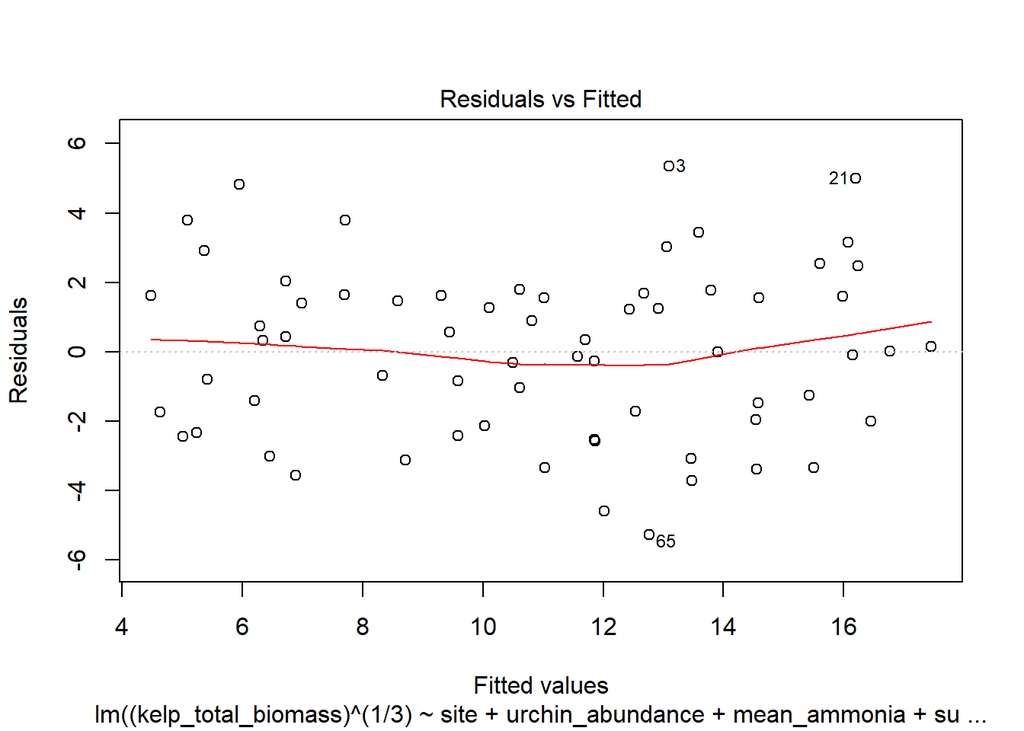

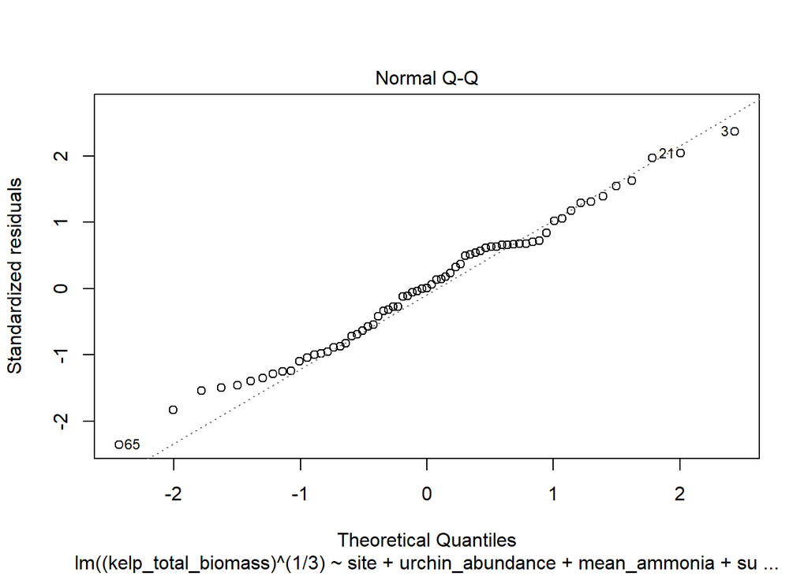

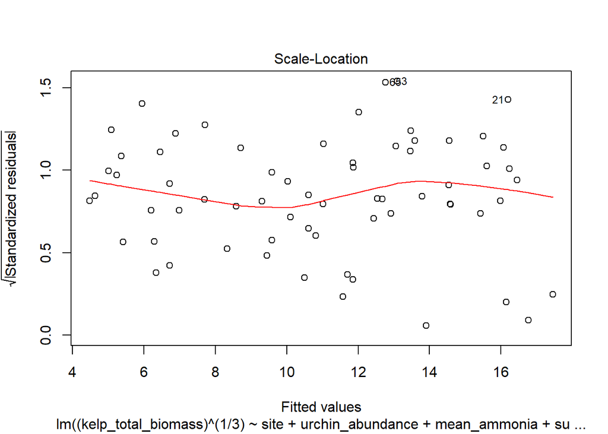

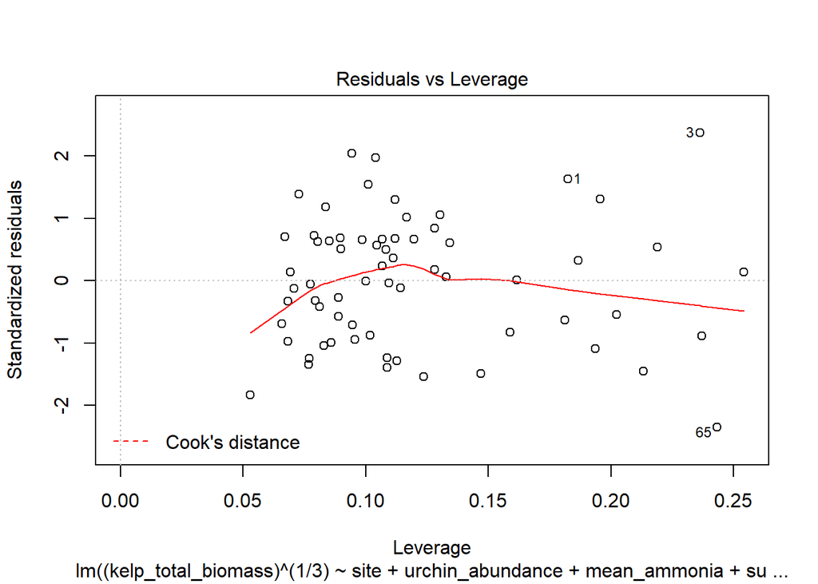

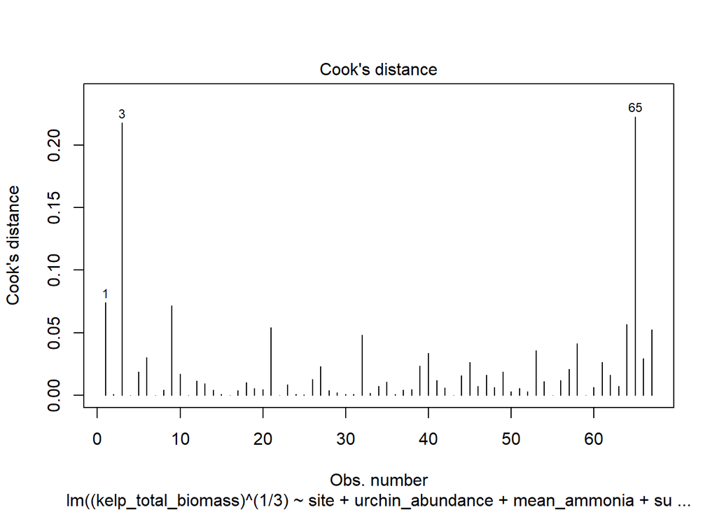

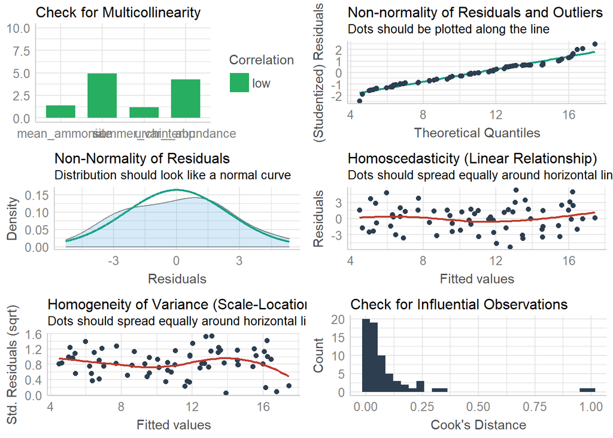

## Random Forest

Data without year:

```
##  [1] "site"               "urchin_abundance"   "mean_ammonia"
##  [4] "mean_no2_no3"       "mean_po4"           "mean_pon"
##  [7] "mean_tchl"          "summer_mean_temp"   "summer_var_temp"
## [10] "kelp_total_biomass" "prev_total_biomass" "urchin_presence"
```

### Optimal Parameters

First, create the grid of parameter combinations

```
##    mtry node_size sampe_size OOB_RMSE
## 1     4         6       0.70 2.885829
## 2     4         7       0.80 2.885872
## 3     4         6       0.80 2.888500
## 4     4         4       0.70 2.889179
## 5     4         4       0.65 2.889204
## 6     4         5       0.65 2.890146
## 7     4         7       0.65 2.891133
## 8     4         7       0.70 2.891334
## 9     4         6       0.65 2.891552
## 10    4         5       0.80 2.894053
```

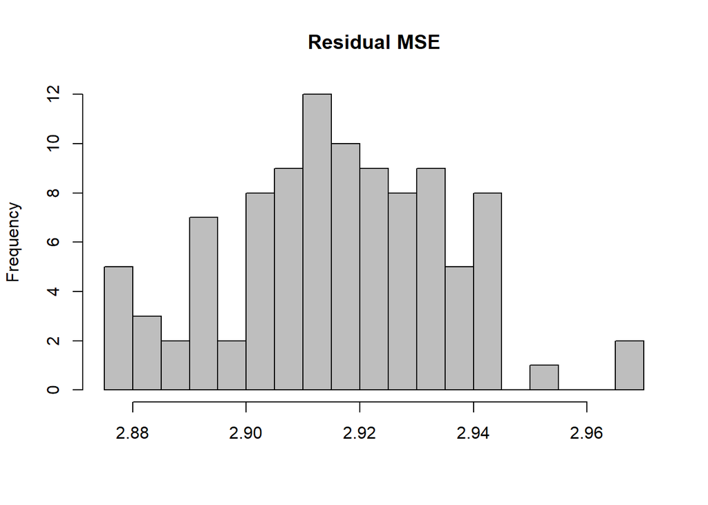

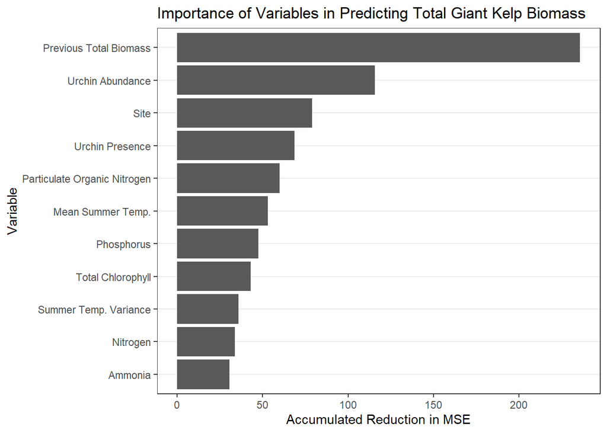

Get training data

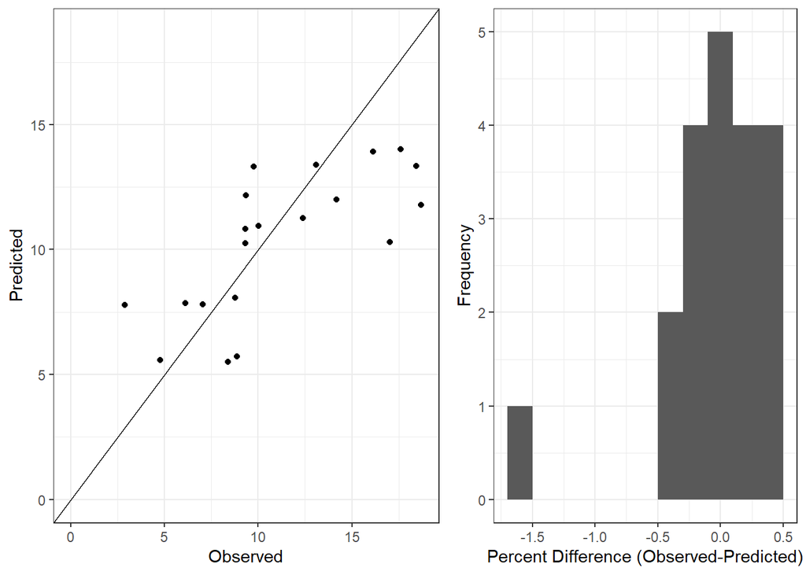